# Debuting with MIMIC 3 and R - Part II: Working Around Albumine

7 minute read

One of the question we get interested in is the influence of the albumine on the survival rate.

First, we find all the items related to albumine.

```r
query <- "select * from mimiciii.D_ITEMS where label ~~* '%albumin%';"
item.albumin <- sqldf(query)
```

```r
query <- "select * from mimiciii.D_ITEMS where label ~~* '%albumin%';"
item.albumin <- sqldf(query)
```

```
##   row_id itemid                     label                     fluid
## 1    269  51069            ALBUMIN, URINE                     URINE
## 2    270  51070 ALBUMIN/CREATININE, URINE                     URINE
## 3    755  51555  SURFACTANT ALBUMIN RATIO          OTHER BODY FLUID
## 4     36  50835          ALBUMIN, ASCITES                   ASCITES
## 5     63  50862                   ALBUMIN                     BLOOD
## 6    211  51011                 <ALBUMIN> CEREBROSPINAL FLUID (CSF)
## 7    219  51019      ALBUMIN, JOINT FLUID               JOINT FLUID
## 8    225  51025       ALBUMIN, BODY FLUID          OTHER BODY FLUID
## 9    246  51046          ALBUMIN, PLEURAL                   PLEURAL
##    category loinc_code
## 1 CHEMISTRY     1754-1
## 2 CHEMISTRY    14958-3
## 3 CHEMISTRY
## 4 CHEMISTRY     1749-1
## 5 CHEMISTRY     1751-7
## 6 CHEMISTRY     1746-7
## 7 CHEMISTRY
## 8 CHEMISTRY     1747-5
## 9 CHEMISTRY     1748-3
```

In the end, only the lab event interest us, with blood fluid.

### Get Albumine patients data

The question of the day is to study the effect of Albumine on a bunch of patients.

The query may seems a little bit complicated, but do the job. At the patient * admission level, we compile: - the gender of the patient. - if the patient died during the admission time. - the minimum value of albumin in the two days after the admission. - the minimum time between the admission and the first albumin dose. - the length of stay in ICU. - if the patient went in one of this three care unit: – CVICU – SICU – CSICU

```r
# The query:
query.albumine.patient <- "select tab1.*, tab2.los
, tab2.intime
, tab2.num_cvicu
, tab2.num_sicu
, tab2.num_csicu
 from ( select i.*
, a.gender
, a.dob
, a.hospital_expire_flag
, b.deathtime
, b.admittime
, b.dischtime
from  ( select  a.subject_id
, b.hadm_id
, min(case when DATE_PART('day', c.charttime - b.admittime) <3 then c.valuenum else NULL end) as min_value_two_day_after_admission
, min(DATE_PART('day', c.charttime - b.admittime) * 24 + DATE_PART('hour', c.charttime - b.admittime)) as min_diff_hours_admin_treatment
from mimiciii.patients as a
inner join mimiciii.admissions as b
on a.subject_id = b.subject_id
left join mimiciii.labevents as c
on a.subject_id = c.subject_id and c.charttime between b.admittime and b.dischtime
where c.itemid = 50862 -- Albumine only
group by a.subject_id, b.hadm_id ) as i
left join mimiciii.patients as a
on a.subject_id = i.subject_id
left join mimiciii.admissions as b
on i.subject_id = b.subject_id and i.hadm_id = b.hadm_id ) as tab1
left join ( select a.subject_id
, b.hadm_id
, c.los
, c.intime
, j.num_cvicu
, j.num_sicu
, j.num_csicu

from mimiciii.patients as a
inner join mimiciii.admissions as b
on a.subject_id = b.subject_id
left join (
select subject_id
, hadm_id
, min(intime) as min_intime
, sum(case when first_careunit = 'CVICU' then 1 else 0 end) as num_cvicu
, sum(case when first_careunit = 'SICU' then 1 else 0 end) as num_sicu
, sum(case when first_careunit = 'CSICU' then 1 else 0 end) as num_csicu
from mimiciii.icustayevents group by subject_id
, hadm_id) j
on a.subject_id = j.subject_id and b.hadm_id = j.hadm_id
left join mimiciii.icustayevents as c
on a.subject_id = c.subject_id and b.hadm_id = c.hadm_id and j.min_intime = c.intime ) as tab2
on tab1.subject_id = tab2.subject_id and tab1.hadm_id = tab2.hadm_id ;"

# Now, import the data
albumine.patients <- sqldf(query.albumine.patient)

# tighten the table:
albumine.patients.dt <- data.table(albumine.patients)
setnames(albumine.patients.dt, names(albumine.patients.dt), tolower(names(albumine.patients.dt)))
```

```r
albumine.patients.dt2[, list(count = format(.N, big.mark = ",")), by = c("gender")]
```

```
##    gender  count
## 1:      M 12,777
## 2:      F  9,781
```

There is more men than women which add been their albumin measured in laboratory.

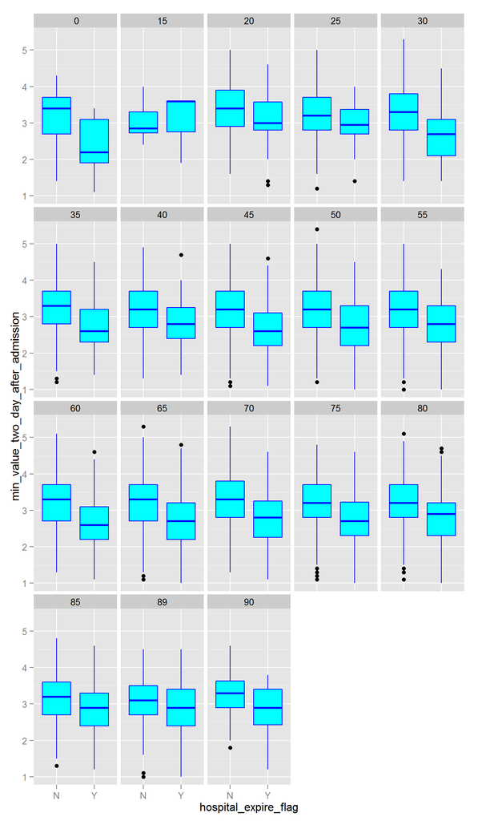

```r
ggplot(data = albumine.patients.dt2, aes(x = hospital_expire_flag, y = min_value_two_day_after_admission)) +
  geom_boxplot(color = "blue", fill = "cyan") +
  facet_wrap(~age, nrow = 4)
```

#### Surgical intensive care unit

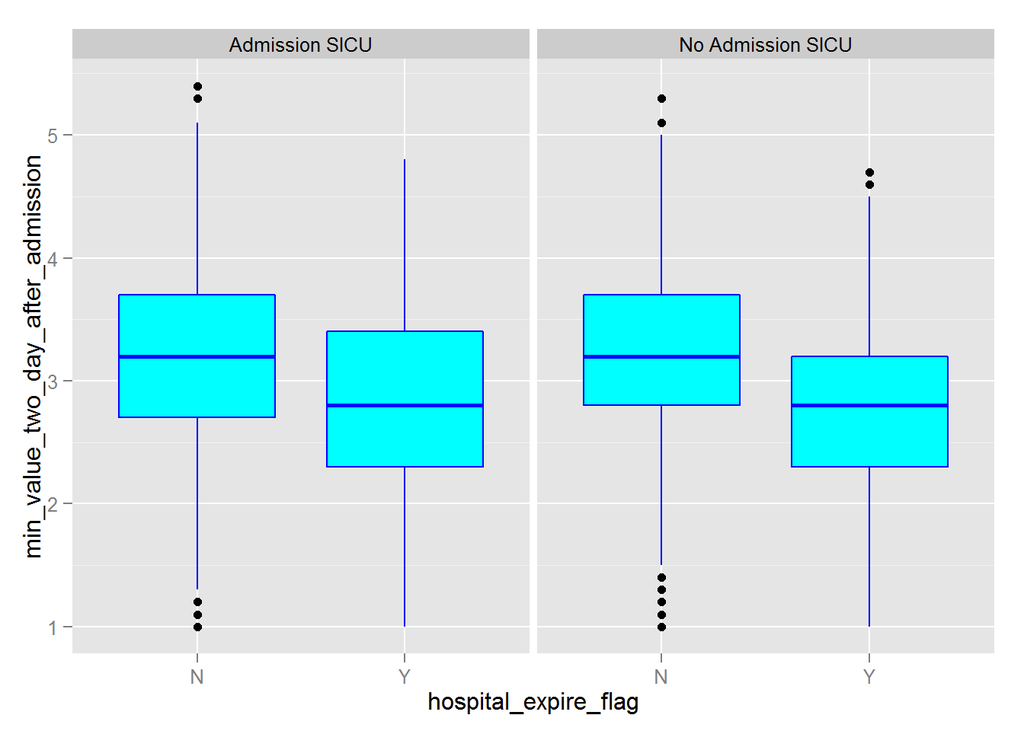

```r
ggplot(data = albumine.patients.dt2, aes(x = hospital_expire_flag, y = min_value_two_day_after_admission)) +
  geom_boxplot(color = "blue", fill = "cyan") +
  facet_wrap(~flg_sicu, nrow = 1)
```

#### Cardiovascular Intensive Care Unit

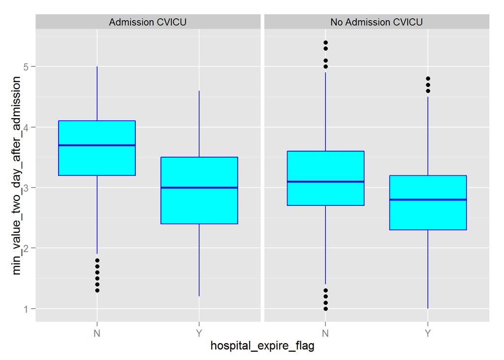

```r
ggplot(data = albumine.patients.dt2, aes(x = hospital_expire_flag, y = min_value_two_day_after_admission)) +
  geom_boxplot(color = "blue", fill = "cyan") +
  facet_wrap(~flg_cvicu, nrow = 1)
```